# The mechanism and magnitude of shrub facilitation changes along a regional gradient of precipitation

Alex Filazzola

Sept 2016

### Ephedra regional gradient (ERG) analyses

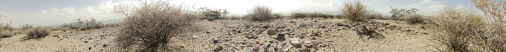

[ecoblender](http://ecoblender.org)

[alex.filazzola](http://www.filazzola.info)

#### Abstract

An under-examined component of the shrub-annual relationship is how regional drivers, such as climate, may alter the sign or magnitude of positive interactions. Interspecific interactions between plants have been shown to be strongly linked to climate, particularly temperature and precipitation. The stress-gradient hypothesis (SGH) predicts that higher abiotic stress (i.e. for deserts, increasing temperature and reduced precipitation) will increase the frequency of positive interactions among shrubs and their annual understory. Regional climate gradients also have indirect effects on plant composition, such as determining consumer abundance and soil nutrient composition. Nutrient availability is particularly affected by precipitation because of altered decomposition rates of organic matter and mineralization. Therefore, the strength of facilitation and operating mechanism of a shrub on the annual plant community may change along a regional gradient.

#### Hypothesis

We tested the hypothesis that positive interactions among shrubs and annual plants will increase with abiotic stress and reduce nutrient availability along a regional gradient of aridity.

#### Methods

[figure not shown]

### Aridity gradient - climate data

DeMartonne’s aridity gradient for each of the seven sites for the last 110 years

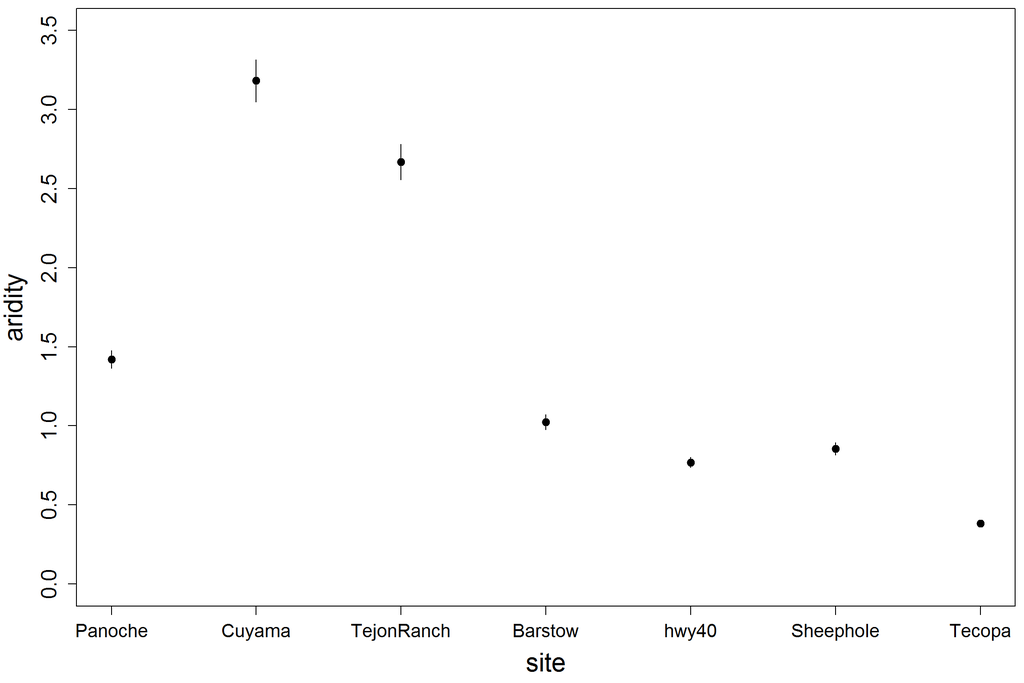

### Weather for growing season

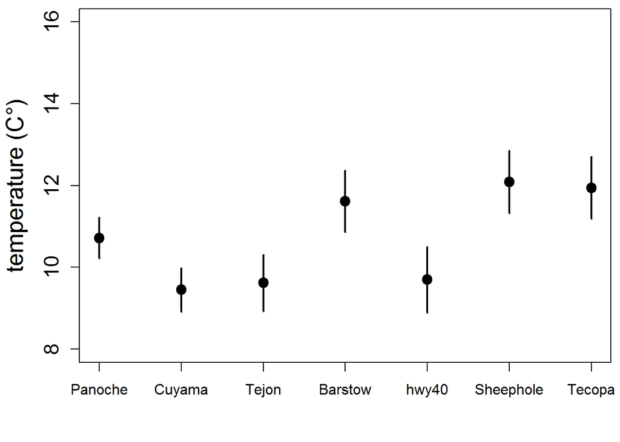

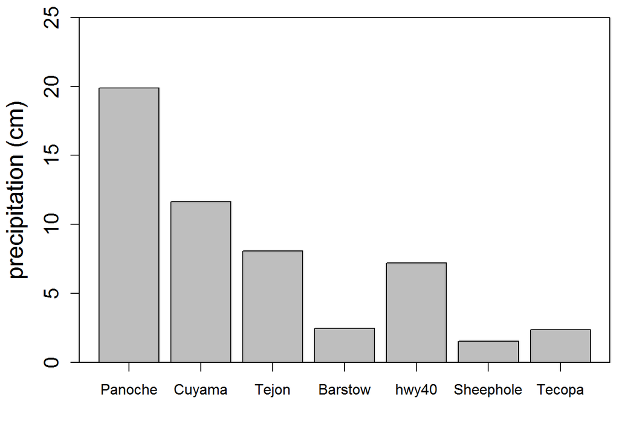

### Nutrient analysis of soil

We compared the soil nutrient content for Nitrogen, Potassium and Phoshporus in shrub and open microsites along all seven sites of the gradient.

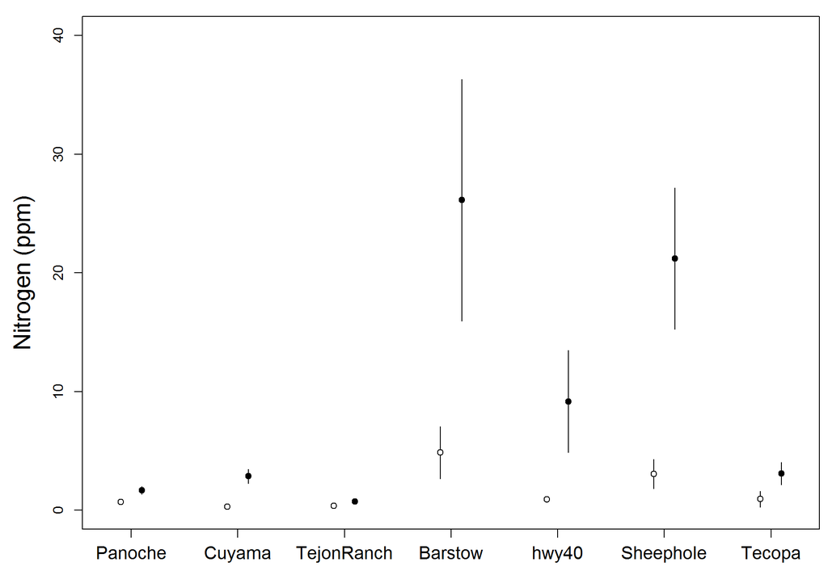

```
## Analysis of Variance Table
##
## Response: N
##                    Df Sum Sq Mean Sq F value  Pr(>F)
## gradient            1  56.11  56.108  0.9934 0.34242
## microsite           1 206.22 206.223  3.6513 0.08509 .
## gradient:microsite  1  32.39  32.391  0.5735 0.46634
## Residuals          10 564.80  56.480
## ---
## Signif. codes:  0 '***' 0.001 '**' 0.01 '*' 0.05 '.' 0.1 ' ' 1
```

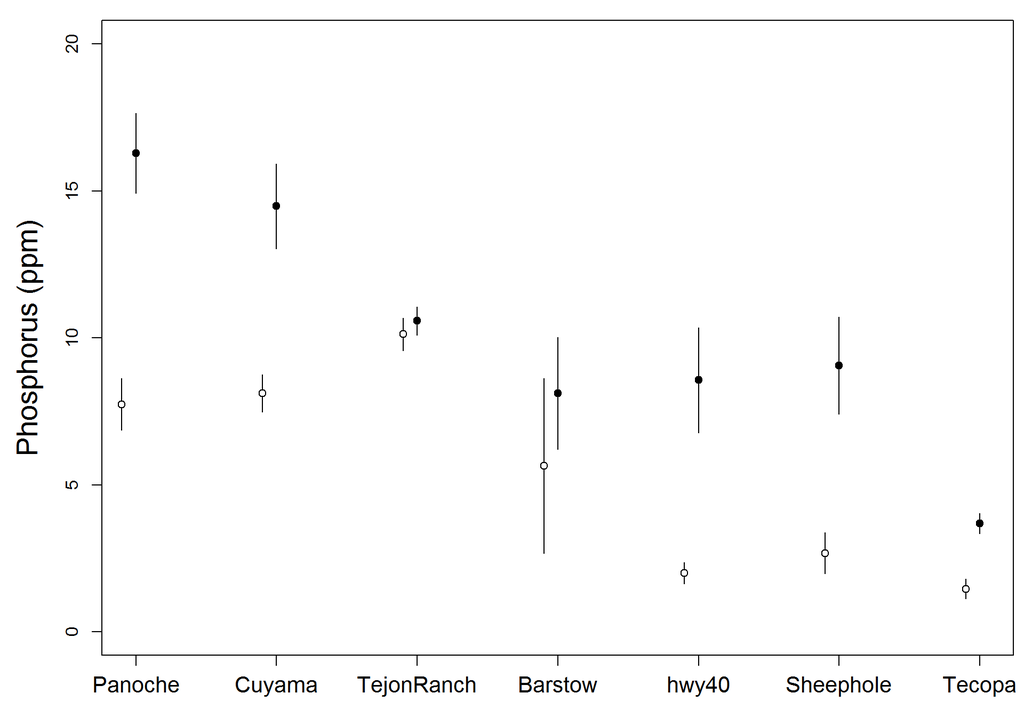

```
## Analysis of Variance Table
##
## Response: P
##                    Df  Sum Sq Mean Sq F value    Pr(>F)
## gradient            1 139.862 139.862 42.2645 6.886e-05 ***
## microsite           1  77.786  77.786 23.5059 0.0006731 ***
## gradient:microsite  1   2.935   2.935  0.8869 0.3685175
## Residuals          10  33.092   3.309
## ---
## Signif. codes:  0 '***' 0.001 '**' 0.01 '*' 0.05 '.' 0.1 ' ' 1
```

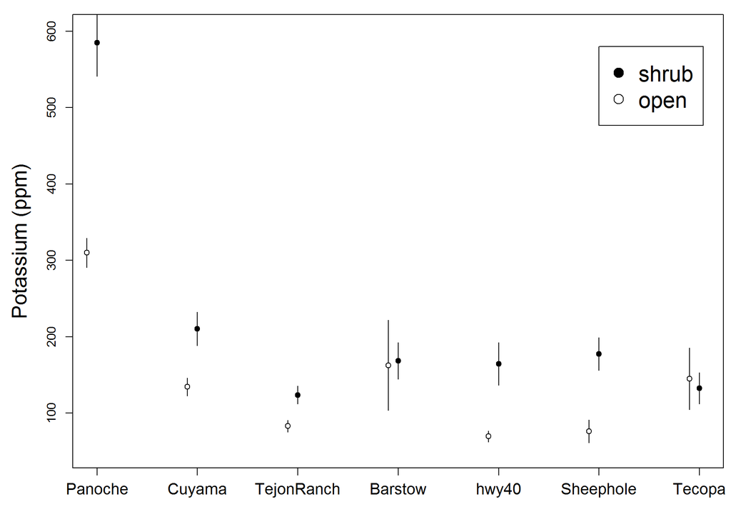

```
## Analysis of Variance Table
##
## Response: K
##                    Df Sum Sq Mean Sq F value  Pr(>F)
## gradient            1  71929   71929  6.1357 0.03271 *
## microsite           1  24161   24161  2.0610 0.18164
## gradient:microsite  1  10233   10233  0.8729 0.37217
## Residuals          10 117231   11723
## ---
## Signif. codes:  0 '***' 0.001 '**' 0.01 '*' 0.05 '.' 0.1 ' ' 1
```

### Microenvironmental differences

We compared temperature and relative humidity between shrub and open microsites among all sites along the regional gradient

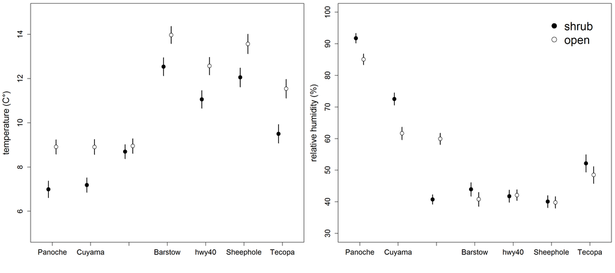

```
    Shapiro-Wilk normality test

data:  fit1$residuals
W = 0.99619, p-value = 0.3875
```

```
                Df Sum Sq Mean Sq F value   Pr(>F)
micro            1  2.435  2.4352 212.262  < 2e-16 ***
gradient         6 17.962  2.9937 260.943  < 2e-16 ***
micro:gradient   6  0.528  0.0880   7.667 7.89e-08 ***
Residuals      420  4.818  0.0115
---
Signif. codes:  0 '***' 0.001 '**' 0.01 '*' 0.05 '.' 0.1 ' ' 1
```

```
Analysis of Deviance Table

Model: binomial, link: logit

Response: RH/100

Terms added sequentially (first to last)

               Df Deviance Resid. Df Resid. Dev  Pr(>Chi)
NULL                             433     61.511
micro           1    0.023       432     61.488    0.8783
gradient        6   51.266       426     10.222 2.619e-09 ***
micro:gradient  6    3.943       420      6.279    0.6844
---
Signif. codes:  0 '***' 0.001 '**' 0.01 '*' 0.05 '.' 0.1 ' ' 1
```

### phytometer preliminary analysis

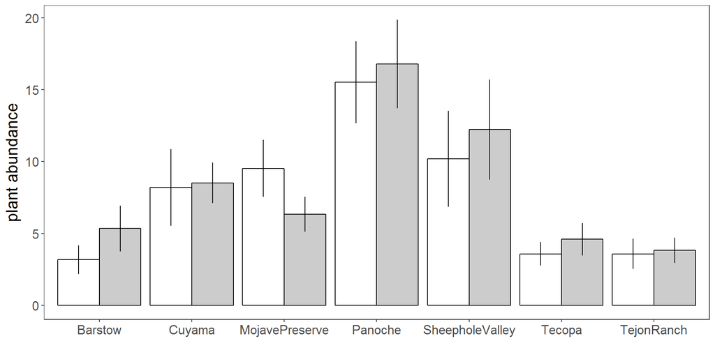

```r
##load phytometer data

data <- read.csv("data/ERG.census2016.csv")


## functions
se <- function(x) sqrt(var(x)/length(x))
conf95 <- function(x) (sd(x)/sqrt(length(x)))*1.96

bar.plots <- function(data, ...) {
## plots
y.min <- data[,3]-data[,5]
y.max <- data[,3]+data[,5]

plot1<- ggplot(data, aes(x=data[,1], y=data[,3], fill=data[,2]))+geom_bar(stat="identity",position=position_dodge(.9), colour="black") +  scale_fill_manual(values=c("#FFFFFF","#CCCCCC"))+
theme_bw()+   guides(fill=FALSE)+
geom_errorbar(aes(ymin=y.min,ymax=y.max, width=0), position=position_dodge(.9))+  xlab("") +
theme(text=element_text(size=16, color="black"),panel.grid.minor=element_blank(),panel.grid.major=element_blank()) + ...

return(plot1)
}

## compare plant abundance and richness
data2 <- subset(data, abundance>0)

abd <- aggregate(abundance ~ Site + Microsite, data=data2, FUN=function (x) c(avg = mean(x),SE = se(x),ci = conf95(x),n = length(x)))
abd <- cbind(abd[,1:2],data.frame(abd[[3]])) ## convert from matrix to dataframe
bar.plots(abd, ylab("plant abundance"))
```

[figure not shown]

```r
rich <- aggregate(abundance ~ Site + Microsite, data=data2, FUN=function (x) c(avg = mean(x),SE = se(x),ci = conf95(x),n = length(x)))
rich <- cbind(rich[,1:2],data.frame(rich[[3]])) ## convert from matrix to dataframe
bar.plots(rich, ylab("species richness"))
```

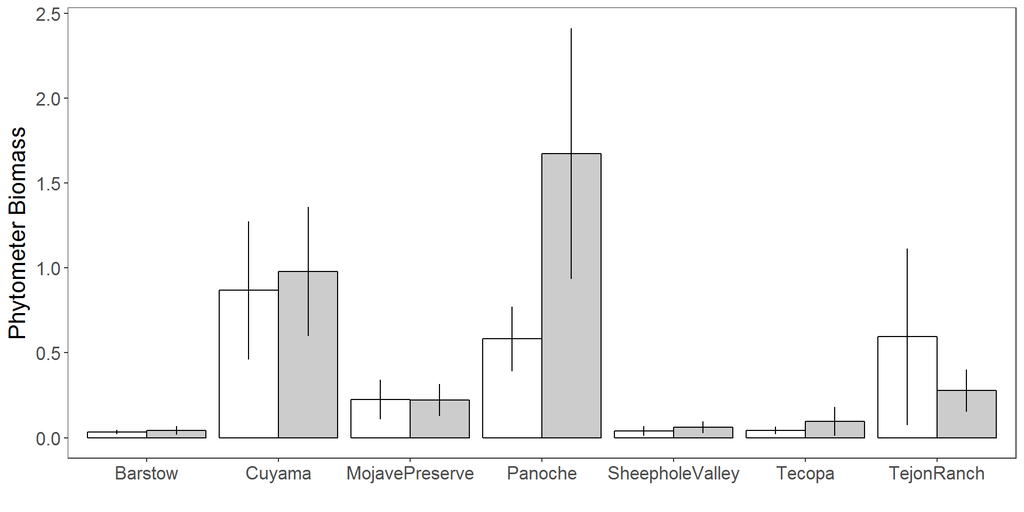

```r
data3 <- subset(data, phyto.biomass>0)
##biomass
biomass <- aggregate(phyto.biomass ~ Site + Microsite, data=data3, FUN=function (x) c(avg = mean(x),SE = se(x),ci = conf95(x),n = length(x)))
biomass <- data.frame(biomass[,1:2],data.frame(biomass[[3]])) ## convert from matrix to dataframe
bar.plots(biomass, ylab("Phytometer Biomass"))
```